# NBA Shot Selection Analysis

Vatsal Baherwani and Joseph Vincent

# Introduction

The NBA is the world's largest basketball league, generating over $10 billion in revenue every year. It is also the 3rd overall largest sports league in the world. Teams are put under great pressure to win games, as this determines the popularity and success of each franchise. The most successful teams get an opportunity to compete in the NBA playoffs, which sell high-demand tickets and attract millions of TV viewers, resulting in additional millions of dollars of revenue. Teams are incentivized to win as many games as possible, but it is very hard to win in this league, and even harder to sustain winning teams over multiple seasons. Thus, it is in the interest of teams to figure out how to score the ball efficiently and frequently to put themselves in the best situation to win.

We will walk you through an analysis of shot selection in the NBA for the 2022-23 regular season. We will be analyzing the types of shots that are most successful and the shots and other factors that are correlated to winning games. We will also explore specific situations, such as: what are common shots taken towards the end of games, what types of shots are taken by the best players, what shots correspond to high scoring games, etc.

```python
%pip install nba-api statsmodels fuzzywuzzy python-Levenshtein
```

```python
from nba_api.stats.endpoints import shotchartdetail, leaguegamelog

# data collection
import json
import requests
from bs4 import BeautifulSoup

# data processing
import pandas as pd
import numpy as np
import fuzzywuzzy.process

# data visualization
import matplotlib.pyplot as plt
import matplotlib as mpl
from mpl_toolkits.axes_grid1.inset_locator import inset_axes

# modelling
import statsmodels.api as sma
import scipy.stats
from sklearn import cluster, svm

%matplotlib inline
```

# Collecting Data

We collect data from BasketballReference describing per-game stats for every player in the 2022-23 NBA season.

```python
response = requests.get('https://www.basketball-reference.com/leagues/NBA_2023_per_game.html')
parsed = BeautifulSoup(response.text)
tbl = parsed.body.find(id='per_game_stats').prettify()
pergamestats = pd.read_html(tbl)[0]
```

We also use NBA API (which scrapes stats.nba.com) to collect data for shot charts and game logs. Shot charts will show locations of every shot taken by players, and the game log describes each of the 1230 games played during the season along with box score stats. To avoid overloading the API and potentially getting blacklisted, we only request once and save the data in a JSON file.

For some background on shot charts and how they can help us understand basketball games, see: https://hoop-social.com/the-leagues-wildest-shot-charts-in-2022-23/

```python
# See https://github.com/swar/nba_api/blob/master/docs/nba_api/stats/endpoints/shotchartdetail.md
# response = shotchartdetail.ShotChartDetail(
#     team_id=0,
#     player_id=0,
#     season_nullable='2022-23',
#     context_measure_simple = 'FGA',
#     season_type_all_star='Regular Season',
# )

# content = json.loads(response.get_json())
# with open('shotchart.json', 'w') as f:
#     json.dump(content, f)

with open('shotchart.json', 'r') as f:
    content = json.loads(f.read())
results = content['resultSets'][0]
headers = results['headers']
rows = results['rowSet']
shotchart = pd.DataFrame(rows, columns=headers)
```

```python
# See https://github.com/swar/nba_api/blob/master/docs/nba_api/stats/endpoints/leaguegamelog.md
# response = leaguegamelog.LeagueGameLog(season='2022-23')

# content = json.loads(response.get_json())
# with open('gamelog.json', 'w') as f:
#     json.dump(content, f)

with open('gamelog.json', 'r') as f:
    content = json.loads(f.read())
results = content['resultSets'][0]
headers = results['headers']
rows = results['rowSet']
gamelog = pd.DataFrame(rows, columns=headers)
gamelog
```

|  | SEASON_ID | TEAM_ID | TEAM_ABBREVIATION | TEAM_NAME | GAME_ID | GAME_DATE | MATCHUP | WL | MIN | FGM | ... | DREB | REB | AST | STL | BLK | TOV | PF | PTS | PLUS_MINUS | VIDEO_AVAILABLE |
| --- | --- | --- | --- | --- | --- | --- | --- | --- | --- | --- | --- | --- | --- | --- | --- | --- | --- | --- | --- | --- | --- |
| 0 | 22022 | 1610612738 | BOS | Boston Celtics | 0022200001 | 2022-10-18 | BOS vs. PHI | W | 240 | 46 | ... | 30 | 36 | 24 | 8 | 3 | 11 | 24 | 126 | 9 | 1 |
| 1 | 22022 | 1610612755 | PHI | Philadelphia 76ers | 0022200001 | 2022-10-18 | PHI @ BOS | L | 240 | 40 | ... | 27 | 31 | 16 | 8 | 3 | 14 | 25 | 117 | -9 | 1 |
| 2 | 22022 | 1610612744 | GSW | Golden State Warriors | 0022200002 | 2022-10-18 | GSW vs. LAL | W | 240 | 45 | ... | 37 | 48 | 31 | 11 | 4 | 18 | 23 | 123 | 14 | 1 |
| 3 | 22022 | 1610612747 | LAL | Los Angeles Lakers | 0022200002 | 2022-10-18 | LAL @ GSW | L | 240 | 40 | ... | 39 | 48 | 23 | 12 | 4 | 22 | 18 | 109 | -14 | 1 |
| 4 | 22022 | 1610612756 | PHX | Phoenix Suns | 0022200013 | 2022-10-19 | PHX vs. DAL | W | 240 | 40 | ... | 32 | 40 | 25 | 4 | 5 | 12 | 29 | 107 | 2 | 1 |
| ... | ... | ... | ... | ... | ... | ... | ... | ... | ... | ... | ... | ... | ... | ... | ... | ... | ... | ... | ... | ... | ... |
| 2455 | 22022 | 1610612757 | POR | Portland Trail Blazers | 0022201230 | 2023-04-09 | POR vs. GSW | L | 240 | 38 | ... | 24 | 30 | 25 | 5 | 3 | 14 | 9 | 101 | -56 | 1 |
| 2456 | 22022 | 1610612758 | SAC | Sacramento Kings | 0022201227 | 2023-04-09 | SAC @ DEN | L | 240 | 37 | ... | 24 | 34 | 24 | 7 | 6 | 15 | 18 | 95 | -14 | 1 |
| 2457 | 22022 | 1610612761 | TOR | Toronto Raptors | 0022201221 | 2023-04-09 | TOR vs. MIL | W | 240 | 48 | ... | 38 | 45 | 29 | 8 | 2 | 9 | 19 | 121 | 16 | 1 |
| 2458 | 22022 | 1610612749 | MIL | Milwaukee Bucks | 0022201221 | 2023-04-09 | MIL @ TOR | L | 240 | 38 | ... | 31 | 38 | 28 | 5 | 2 | 14 | 13 | 105 | -16 | 1 |
| 2459 | 22022 | 1610612737 | ATL | Atlanta Hawks | 0022201216 | 2023-04-09 | ATL @ BOS | L | 240 | 44 | ... | 34 | 50 | 27 | 11 | 5 | 9 | 12 | 114 | -6 | 1 |

2460 rows × 29 columns

# Processing Data

The BasketballReference website repeats the column names every 20 rows for ease of viewing, but we will drop these. Also, if a player is on multiple teams they have multiple rows in the dataset, with the first one representing their overall stats. So, we keep that first row out of all the duplicates.

```python
pergamestats.drop(pergamestats[pergamestats.Player == 'Player'].index, inplace=True)
pergamestats.drop_duplicates(subset=['Player'], keep='first', inplace=True)
pergamestats.reset_index(inplace=True)
pergamestats.drop(columns=['index', 'Rk'], inplace=True) # we don't need these anymore
pergamestats
```

|  | Player | Pos | Age | Tm | G | GS | MP | FG | FGA | FG% | ... | FT% | ORB | DRB | TRB | AST | STL | BLK | TOV | PF | PTS |
| --- | --- | --- | --- | --- | --- | --- | --- | --- | --- | --- | --- | --- | --- | --- | --- | --- | --- | --- | --- | --- | --- |
| 0 | Precious Achiuwa | C | 23 | TOR | 55 | 12 | 20.7 | 3.6 | 7.3 | .485 | ... | .702 | 1.8 | 4.1 | 6.0 | 0.9 | 0.6 | 0.5 | 1.1 | 1.9 | 9.2 |
| 1 | Steven Adams | C | 29 | MEM | 42 | 42 | 27.0 | 3.7 | 6.3 | .597 | ... | .364 | 5.1 | 6.5 | 11.5 | 2.3 | 0.9 | 1.1 | 1.9 | 2.3 | 8.6 |
| 2 | Bam Adebayo | C | 25 | MIA | 75 | 75 | 34.6 | 8.0 | 14.9 | .540 | ... | .806 | 2.5 | 6.7 | 9.2 | 3.2 | 1.2 | 0.8 | 2.5 | 2.8 | 20.4 |
| 3 | Ochai Agbaji | SG | 22 | UTA | 59 | 22 | 20.5 | 2.8 | 6.5 | .427 | ... | .812 | 0.7 | 1.3 | 2.1 | 1.1 | 0.3 | 0.3 | 0.7 | 1.7 | 7.9 |
| 4 | Santi Aldama | PF | 22 | MEM | 77 | 20 | 21.8 | 3.2 | 6.8 | .470 | ... | .750 | 1.1 | 3.7 | 4.8 | 1.3 | 0.6 | 0.6 | 0.8 | 1.9 | 9.0 |
| ... | ... | ... | ... | ... | ... | ... | ... | ... | ... | ... | ... | ... | ... | ... | ... | ... | ... | ... | ... | ... | ... |
| 534 | Thaddeus Young | PF | 34 | TOR | 54 | 9 | 14.7 | 2.0 | 3.7 | .545 | ... | .692 | 1.3 | 1.8 | 3.1 | 1.4 | 1.0 | 0.1 | 0.8 | 1.6 | 4.4 |
| 535 | Trae Young | PG | 24 | ATL | 73 | 73 | 34.8 | 8.2 | 19.0 | .429 | ... | .886 | 0.8 | 2.2 | 3.0 | 10.2 | 1.1 | 0.1 | 4.1 | 1.4 | 26.2 |
| 536 | Omer Yurtseven | C | 24 | MIA | 9 | 0 | 9.2 | 1.8 | 3.0 | .593 | ... | .833 | 0.9 | 1.7 | 2.6 | 0.2 | 0.2 | 0.2 | 0.4 | 1.8 | 4.4 |
| 537 | Cody Zeller | C | 30 | MIA | 15 | 2 | 14.5 | 2.5 | 3.9 | .627 | ... | .686 | 1.7 | 2.6 | 4.3 | 0.7 | 0.2 | 0.3 | 0.9 | 2.2 | 6.5 |
| 538 | Ivica Zubac | C | 25 | LAC | 76 | 76 | 28.6 | 4.3 | 6.8 | .634 | ... | .697 | 3.1 | 6.8 | 9.9 | 1.0 | 0.4 | 1.3 | 1.5 | 2.9 | 10.8 |

539 rows × 29 columns

Some stats will have N/A values if there are no such events (for example, N/A FTA if a player never attempted a free throw). This is the same as saying they just shot 0 free throws.

```python
pergamestats.fillna(0, inplace=True)
```

Now that our data is cleaned up, we will convert the types of every column to int or float. Note that this is done because we read from an HTML table which assumes string types. This is not necessary for our NBA API tables because those were loaded from JSON.

```python
for column in pergamestats.columns[6:]:
    pergamestats[column] = pergamestats[column].astype(float)

pergamestats.Age = pergamestats.Age.astype(int)
pergamestats.G = pergamestats.G.astype(int)
pergamestats.GS = pergamestats.GS.astype(int)
```

Looking at the shot chart data below: since the location coordinates in our shot chart are very granular (0.1 foot increments), let's round them by a factor of 5 to minimize the empty groups when we calculate accuracy. This will be useful when we want to look at aggregate statistics for certain spots on the court, as it will avoid empty spots due to a lack of data from that specific point.

```python
shotchart['ROUND_LOC_X'] = np.round(shotchart.LOC_X / 5) * 5
shotchart['ROUND_LOC_Y'] = np.round(shotchart.LOC_Y / 5) * 5

shotchart
```

|  | GRID_TYPE | GAME_ID | GAME_EVENT_ID | PLAYER_ID | PLAYER_NAME | TEAM_ID | TEAM_NAME | PERIOD | MINUTES_REMAINING | SECONDS_REMAINING | ... | SHOT_DISTANCE | LOC_X | LOC_Y | SHOT_ATTEMPTED_FLAG | SHOT_MADE_FLAG | GAME_DATE | HTM | VTM | ROUND_LOC_X | ROUND_LOC_Y |
| --- | --- | --- | --- | --- | --- | --- | --- | --- | --- | --- | --- | --- | --- | --- | --- | --- | --- | --- | --- | --- | --- |
| 0 | Shot Chart Detail | 0022200001 | 7 | 203954 | Joel Embiid | 1610612755 | Philadelphia 76ers | 1 | 11 | 38 | ... | 12 | -118 | 50 | 1 | 0 | 20221018 | BOS | PHI | -120.0 | 50.0 |
| 1 | Shot Chart Detail | 0022200001 | 11 | 203935 | Marcus Smart | 1610612738 | Boston Celtics | 1 | 11 | 15 | ... | 13 | 120 | 55 | 1 | 1 | 20221018 | BOS | PHI | 120.0 | 55.0 |
| 2 | Shot Chart Detail | 0022200001 | 12 | 202699 | Tobias Harris | 1610612755 | Philadelphia 76ers | 1 | 11 | 5 | ... | 14 | 50 | 135 | 1 | 0 | 20221018 | BOS | PHI | 50.0 | 135.0 |
| 3 | Shot Chart Detail | 0022200001 | 14 | 202699 | Tobias Harris | 1610612755 | Philadelphia 76ers | 1 | 11 | 3 | ... | 0 | 0 | 0 | 1 | 1 | 20221018 | BOS | PHI | 0.0 | 0.0 |
| 4 | Shot Chart Detail | 0022200001 | 15 | 1628369 | Jayson Tatum | 1610612738 | Boston Celtics | 1 | 10 | 46 | ... | 23 | -232 | 49 | 1 | 1 | 20221018 | BOS | PHI | -230.0 | 50.0 |
| ... | ... | ... | ... | ... | ... | ... | ... | ... | ... | ... | ... | ... | ... | ... | ... | ... | ... | ... | ... | ... | ... |
| 217215 | Shot Chart Detail | 0022201230 | 634 | 1630541 | Moses Moody | 1610612744 | Golden State Warriors | 4 | 1 | 11 | ... | 1 | 11 | 3 | 1 | 1 | 20230409 | POR | GSW | 10.0 | 5.0 |
| 217216 | Shot Chart Detail | 0022201230 | 636 | 1631219 | John Butler Jr. | 1610612757 | Portland Trail Blazers | 4 | 1 | 0 | ... | 23 | 224 | 84 | 1 | 1 | 20230409 | POR | GSW | 225.0 | 85.0 |
| 217217 | Shot Chart Detail | 0022201230 | 638 | 1630228 | Jonathan Kuminga | 1610612744 | Golden State Warriors | 4 | 0 | 44 | ... | 23 | 199 | 126 | 1 | 0 | 20230409 | POR | GSW | 200.0 | 125.0 |
| 217218 | Shot Chart Detail | 0022201230 | 640 | 1631116 | Patrick Baldwin Jr. | 1610612744 | Golden State Warriors | 4 | 0 | 36 | ... | 8 | -71 | 52 | 1 | 0 | 20230409 | POR | GSW | -70.0 | 50.0 |
| 217219 | Shot Chart Detail | 0022201230 | 642 | 1630219 | Skylar Mays | 1610612757 | Portland Trail Blazers | 4 | 0 | 27 | ... | 12 | -13 | 120 | 1 | 0 | 20230409 | POR | GSW | -15.0 | 120.0 |

217220 rows × 26 columns

We want the shot chart data to be connected to these player stats, so we will merge based on player name. We will also create a dataframe merging the shot chart data with team data, so we can compare the shot selection of winning and losing teams. For this second merged dataframe, we also want to merge on game ID so that we can observe shot charts for specific games.

```python
playershotchart = shotchart.merge(pergamestats, how='left', left_on='PLAYER_NAME', right_on='Player')
teamshotchart = shotchart.merge(gamelog, how='left', on=['GAME_ID', 'TEAM_NAME'])
```

Some of the names won't match when we construct our player shot chart. Since we did a left join, let's see which of the right side Player variables didn't match. These mismatches happen mostly because of leaving out Jr./Sr/III in the name, or accents on some of the letters. To address this, we will use a string similarity metric called the Levenshtein distance to find the closest possible match for these names in the shot chart dataset. This process is also referred to as "fuzzy string searching".

Read more about this metric here: https://en.wikipedia.org/wiki/Levenshtein_distance

Learn more about fuzzy string searching here: https://redis.com/blog/what-is-fuzzy-matching/

```python
missingnames = playershotchart[playershotchart.Player.isna()].PLAYER_NAME.unique()
missingnames
```

```
array(['Bojan Bogdanovic', 'Kevin Knox II', 'Kristaps Porzingis',
       'Alperen Sengun', 'Jonas Valanciunas', 'Nikola Vucevic',
       'Goran Dragic', 'O.G. Anunoby', 'Xavier Tillman', 'Nikola Jokic',
       'Vlatko Cancar', 'Luka Doncic', 'Dario Saric', 'Jusuf Nurkic',
       'Marcus Morris Sr.', 'Willy Hernangomez', 'Boban Marjanovic',
       'Theo Maledon', 'Nikola Jovic', 'Moussa Diabate',
       'Juancho Hernangomez', 'Jeff Dowtin Jr.', 'John Butler Jr.',
       'AJ Green', 'Davis Bertans', 'Dennis Schroder',
       'Bogdan Bogdanovic', 'Robert Williams III', 'Luka Samanic'],
      dtype=object)
```

Let's verify that the names match reasonably. We also want to create a mapping to update the right dataset names to match the left ones.

```python
def find_closest_match(name, choices):
    matches = fuzzywuzzy.process.extract(name, choices)
    return matches[0][0]

# find best match for every name
matches = [find_closest_match(name, pergamestats.Player) for name in missingnames]
matchesdf = pd.DataFrame({'Missing Name': missingnames, 'Match': matches})
display(matchesdf)

# zip to create pairs, and turn it into a mapping
missingnamesmap = dict(zip(matches, missingnames))
pergamestats.loc[pergamestats.Player.isin(matches), 'Player'] = pergamestats.loc[pergamestats.Player.isin(matches), 'Player'].map(missingnamesmap)
```

|  | Missing Name | Match |
| --- | --- | --- |
| 0 | Bojan Bogdanovic | Bojan Bogdanović |
| 1 | Kevin Knox II | Kevin Knox |
| 2 | Kristaps Porzingis | Kristaps Porziņģis |
| 3 | Alperen Sengun | Alperen Şengün |
| 4 | Jonas Valanciunas | Jonas Valančiūnas |
| 5 | Nikola Vucevic | Nikola Vučević |
| 6 | Goran Dragic | Goran Dragić |
| 7 | O.G. Anunoby | OG Anunoby |
| 8 | Xavier Tillman | Xavier Tillman Sr. |
| 9 | Nikola Jokic | Nikola Jokić |
| 10 | Vlatko Cancar | Vlatko Čančar |
| 11 | Luka Doncic | Luka Dončić |
| 12 | Dario Saric | Dario Šarić |
| 13 | Jusuf Nurkic | Jusuf Nurkić |
| 14 | Marcus Morris Sr. | Marcus Morris |
| 15 | Willy Hernangomez | Willy Hernangómez |
| 16 | Boban Marjanovic | Boban Marjanović |
| 17 | Theo Maledon | Théo Maledon |
| 18 | Nikola Jovic | Nikola Jović |
| 19 | Moussa Diabate | Moussa Diabaté |
| 20 | Juancho Hernangomez | Juancho Hernangómez |
| 21 | Jeff Dowtin Jr. | Jeff Dowtin |
| 22 | John Butler Jr. | John Butler |
| 23 | AJ Green | A.J. Green |
| 24 | Davis Bertans | Dāvis Bertāns |
| 25 | Dennis Schroder | Dennis Schröder |
| 26 | Bogdan Bogdanovic | Bogdan Bogdanović |
| 27 | Robert Williams III | Robert Williams |
| 28 | Luka Samanic | Luka Šamanić |

Let's try merging again now. Now, there'll be no more missing names.

```python
playershotchart = shotchart.merge(pergamestats, how='left', left_on='PLAYER_NAME', right_on='Player')
playershotchart[playershotchart.Player.isna()].PLAYER_NAME.unique()
```

```
array([], dtype=object)
```

Now we will pick out the columns that we really need from all 5 of our dataframes, and drop the rest.

```python
shotchart = shotchart[[
    'PLAYER_NAME', 'TEAM_NAME',
    'PERIOD', 'MINUTES_REMAINING', 'SECONDS_REMAINING',
    'ACTION_TYPE', 'SHOT_TYPE', 'SHOT_ZONE_BASIC', 'SHOT_DISTANCE',
    'LOC_X', 'LOC_Y', 'ROUND_LOC_X', 'ROUND_LOC_Y', 'SHOT_MADE_FLAG']]

pergamestats # will stay the same

gamelog # will stay the same

playershotchart = playershotchart[[
    'PLAYER_NAME', 'TEAM_NAME',
    'PERIOD', 'MINUTES_REMAINING', 'SECONDS_REMAINING',
    'ACTION_TYPE', 'SHOT_TYPE', 'SHOT_ZONE_BASIC', 'SHOT_DISTANCE',
    'LOC_X', 'LOC_Y', 'ROUND_LOC_X', 'ROUND_LOC_Y', 'SHOT_MADE_FLAG',
    'Pos', 'Age', 'GS', 'FGA', 'FG%', '3P%', '2P%', 'eFG%', 'FT%', 'PTS']]

teamshotchart = teamshotchart[[
    'PLAYER_NAME', 'TEAM_NAME',
    'PERIOD', 'MINUTES_REMAINING', 'SECONDS_REMAINING',
    'ACTION_TYPE', 'SHOT_TYPE', 'SHOT_ZONE_BASIC', 'SHOT_DISTANCE',
    'LOC_X', 'LOC_Y', 'ROUND_LOC_X', 'ROUND_LOC_Y', 'SHOT_MADE_FLAG',
    'WL', 'FG_PCT', 'FG3_PCT', 'FT_PCT', 'PTS', 'PLUS_MINUS'
]]
```

# Exploratory Data Analysis + Data Visualization

For more information about eFG% as a metric and why it is so important to winning, see: https://www.breakthroughbasketball.com/stats/effective-field-goal-percentage.html

```
Normality t-statistic: 175.82; p-value: 6.615349793997254e-39
```

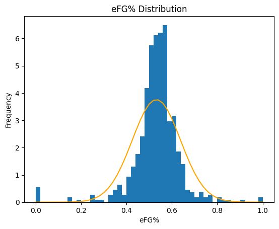

```python
stat, p = scipy.stats.normaltest(pergamestats['eFG%'])
print(f'Normality t-statistic: {stat:0.2f}; p-value: {p}')

n, bins, patches = plt.hist(pergamestats['eFG%'], density=True, bins=50)
mean, std = scipy.stats.norm.fit(pergamestats['eFG%'])
plt.plot(bins, scipy.stats.norm.pdf(bins, mean, std), c='orange')

plt.title('eFG% Distribution')
plt.xlabel('eFG%')
plt.ylabel('Frequency')
plt.show()
```

This normal distribution has fat tails, largely because of the outliers. What do these outliers look like in the data? It turns out that these are very small sample sizes i.e. the players only played a few games and either shot really well or really poorly. In the following analysis, we will want to filter for players that played a decent amount of games.

```python
pergamestats[(pergamestats['eFG%'] > 0.85) | (pergamestats['eFG%'] < 0.15)]
```

|  | Player | Pos | Age | Tm | G | GS | MP | FG | FGA | FG% | ... | FT% | ORB | DRB | TRB | AST | STL | BLK | TOV | PF | PTS |
| --- | --- | --- | --- | --- | --- | --- | --- | --- | --- | --- | --- | --- | --- | --- | --- | --- | --- | --- | --- | --- | --- |
| 66 | Sterling Brown | SG | 27 | LAL | 4 | 0 | 6.0 | 0.0 | 1.0 | 0.000 | ... | 0.0 | 0.8 | 1.3 | 2.0 | 0.5 | 0.8 | 0.0 | 0.0 | 1.0 | 0.0 |
| 72 | Deonte Burton | SG | 29 | SAC | 2 | 0 | 3.0 | 0.0 | 1.0 | 0.000 | ... | 0.0 | 0.0 | 0.0 | 0.0 | 0.0 | 0.0 | 0.0 | 0.0 | 0.0 | 0.0 |
| 125 | Tyler Dorsey | SG | 26 | DAL | 3 | 0 | 2.7 | 1.3 | 1.7 | 0.800 | ... | 0.0 | 0.3 | 0.3 | 0.7 | 0.0 | 0.0 | 0.0 | 0.0 | 0.0 | 3.0 |
| 150 | Michael Foster Jr. | PF | 20 | PHI | 1 | 0 | 1.0 | 0.0 | 0.0 | 0.000 | ... | 0.0 | 0.0 | 0.0 | 0.0 | 0.0 | 0.0 | 0.0 | 0.0 | 0.0 | 0.0 |
| 232 | Frank Jackson | PG | 24 | UTA | 1 | 0 | 5.0 | 0.0 | 3.0 | 0.000 | ... | 0.0 | 1.0 | 1.0 | 2.0 | 1.0 | 0.0 | 0.0 | 0.0 | 0.0 | 0.0 |
| 265 | Braxton Key | SF | 25 | DET | 3 | 0 | 3.0 | 0.3 | 0.3 | 1.000 | ... | 1.0 | 0.0 | 0.3 | 0.3 | 0.0 | 0.0 | 0.0 | 0.0 | 0.0 | 1.3 |
| 434 | Jay Scrubb | SG | 22 | ORL | 2 | 0 | 15.0 | 2.5 | 3.5 | 0.714 | ... | 0.5 | 0.0 | 3.0 | 3.0 | 0.5 | 1.0 | 0.0 | 1.5 | 1.0 | 6.5 |
| 442 | Chris Silva | PF | 26 | DAL | 1 | 0 | 3.0 | 1.0 | 1.0 | 1.000 | ... | 0.0 | 0.0 | 0.0 | 0.0 | 0.0 | 0.0 | 0.0 | 1.0 | 2.0 | 2.0 |
| 481 | Stanley Umude | SG | 23 | DET | 1 | 0 | 2.0 | 0.0 | 1.0 | 0.000 | ... | 1.0 | 0.0 | 0.0 | 0.0 | 0.0 | 1.0 | 1.0 | 0.0 | 0.0 | 2.0 |
| 514 | Alondes Williams | SG | 23 | BRK | 1 | 0 | 5.0 | 0.0 | 0.0 | 0.000 | ... | 0.0 | 0.0 | 1.0 | 1.0 | 0.0 | 0.0 | 0.0 | 2.0 | 1.0 | 0.0 |

10 rows × 29 columns

We define rotation players as players that played at least 20 games in the season, and averaged at least 12 minutes a game (25% of the full 48 minutes). These are the players that are in the general rotation of 5-man lineups that coaches cycle through, so we can be sure that they have an ample amount of shot attempts to calculate eFG%. Now the eFG% distribution is much smoother, and we see the steep drop-off of players averaging an eFG% above about 57%.

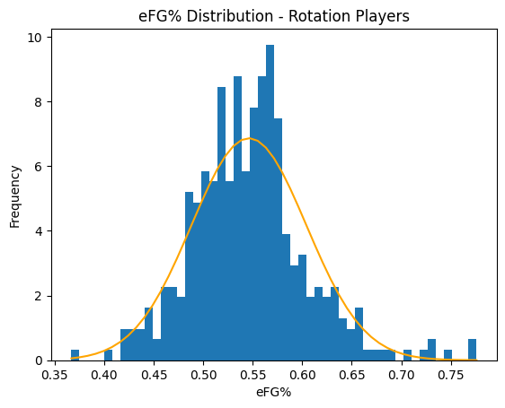

```python
rotationplayers = pergamestats[(pergamestats['G'] > 20) & (pergamestats['MP'] >= 12)]

n, bins, patches = plt.hist(rotationplayers['eFG%'], density=True, bins=50)
mean, std = scipy.stats.norm.fit(rotationplayers['eFG%'])
plt.plot(bins, scipy.stats.norm.pdf(bins, mean, std), c='orange')

plt.title('eFG% Distribution - Rotation Players')
plt.xlabel('eFG%')
plt.ylabel('Frequency')
plt.show()
```

How many points do each of these players score? Let's also group these players by what position they play. It turns out that most players with high eFG% are centers, and this makes sense as they rarely take shots outside of the paint. They also tend to score not as much; the top scorers have an eFG% close to the league average. However, there are some prolific scorers that score plentifully and efficiently. We note these players below.

For more information about player positions in the NBA and their roles, see: https://jr.nba.com/basketball-positions/

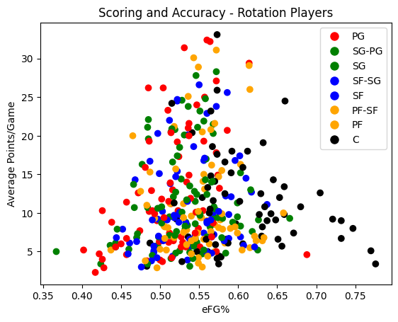

```
array([['Nikola Jokic', 'C', 24.5, 0.66],
       ['Zion Williamson', 'PF', 26.0, 0.615],
       ['Stephen Curry', 'PG', 29.4, 0.614],
       ['Kevin Durant', 'PF-SF', 29.1, 0.614],
       ['Tyrese Haliburton', 'PG', 20.7, 0.586],
       ['Lauri Markkanen', 'SF', 25.6, 0.586],
       ['Anthony Davis', 'C', 25.9, 0.573],
       ['Joel Embiid', 'C', 33.1, 0.573],
       ['Giannis Antetokounmpo', 'PF', 31.1, 0.572],
       ['Kyrie Irving', 'PG', 27.1, 0.572],
       ['Kawhi Leonard', 'SF', 23.8, 0.572],
       ['Donovan Mitchell', 'SG', 28.3, 0.572]], dtype=object)
```

```python
x = rotationplayers['eFG%']
y = rotationplayers['PTS']

colors = {'PG':'red', 'SG-PG':'green', 'SG': 'green', 'SF-SG': 'blue', 'SF': 'blue','PF-SF':'orange', 'PF': 'orange', 'C': 'black'}

# manually draw our legend with each of different color mappings
patches = [plt.plot([], [], marker='o', ms=10, ls='', mec='white', mfc=color, label=label)[0] for label, color in colors.items()]
plt.legend(handles=patches, loc='best')

plt.scatter(x , y, c=rotationplayers['Pos'].map(colors))
plt.title('Scoring and Accuracy - Rotation Players')
plt.xlabel('eFG%')
plt.ylabel('Average Points/Game')
plt.show()

# sort by highest efficiency first
rotationplayers[(rotationplayers['PTS'] > 20) & (rotationplayers['eFG%'] > 0.57)].sort_values(by='eFG%', ascending=False)[['Player','Pos', 'PTS', 'eFG%']].values
```

Now we will look at the shot chart data. Let's begin by visualizing what shot charts look like for certain players. The shot data is relative to the rim, which is 6 feet away from the edge of the court, so we offset the Y coordinate by 60 to fit into the court drawing.

To learn more about NBA court dimensions and the numbers that we use in this drawing, see: https://official.nba.com/rule-no-1-court-dimensions-equipment/

```python
# Source for coordinates: https://www.kaggle.com/code/ubiratanfilho/creating-nba-shot-charts
def draw_court():
    fig, ax = plt.subplots(figsize=(5*1.5, 4.7*1.5))
    color='black'

    ax.plot([-220, -220], [0, 140], linewidth=1, color=color)
    ax.plot([220, 220], [0, 140], linewidth=1, color=color)
    ax.add_artist(mpl.patches.Arc((0, 140), 440, 315, theta1=0, theta2=180, facecolor='none', edgecolor=color, lw=1))


    ax.plot([-80, -80], [0, 190], linewidth=1, color=color)
    ax.plot([80, 80], [0, 190], linewidth=1, color=color)
    ax.plot([-60, -60], [0, 190], linewidth=1, color=color)
    ax.plot([60, 60], [0, 190], linewidth=1, color=color)
    ax.plot([-80, 80], [190, 190], linewidth=1, color=color)
    ax.add_artist(mpl.patches.Circle((0, 190), 60, facecolor='none', edgecolor=color, lw=1))
    ax.plot([-250, 250], [0, 0], linewidth=1, color=color)
    ax.plot([-250, 250], [470, 470], linewidth=1, color=color)

    ax.add_artist(mpl.patches.Circle((0, 60), 15, facecolor='none', edgecolor=color, lw=1))
    ax.plot([-30, 30], [40, 40], linewidth=1, color=color)

    ax.set_xticks([])
    ax.set_yticks([])

    ax.set_xlim(-250, 250)
    ax.set_ylim(0, 470)

    return fig, ax
```

Given the high volume of shots taken throughout an 82-game, plotting every single one is not insightful. We will instead use a hexbin plot that will filter for locations that multiple shots are taken from (at least 2). Also, the bins will be labeled by their log frequency. In the plot below, green and yellow represent high frequency shots for 2x MVP point guard Stephen Curry.

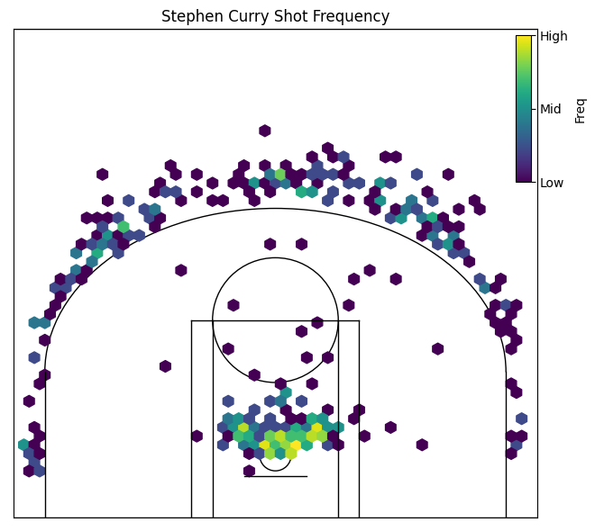

```python
def shot_frequency_chart(chart, title, mincnt=2):
    fig, ax = draw_court()
    # 50 by 50 hex grid, bounded by our court dimensions
    hexbin = ax.hexbin(chart.LOC_X, chart.LOC_Y + 60, cmap='viridis', bins='log', gridsize=50, mincnt=mincnt, extent=(-250, 250, 422.5, -47.5))

    # create colorbar with 3 tick labels
    cbaxes = inset_axes(ax, width="3%", height="30%", loc=1)
    cb = plt.colorbar(plt.cm.ScalarMappable(cmap='viridis'), cax=cbaxes, label='Freq', orientation='vertical')
    cb.set_ticks([0, 0.5, 1])
    cb.set_ticklabels(['Low', 'Mid', 'High'])

    ax.set_title(title)
    plt.show()

shot_frequency_chart(shotchart[shotchart['PLAYER_NAME'] == 'Stephen Curry'], 'Stephen Curry Shot Frequency')
```

Shot charts vary drastically between players. Here is the chart for 2x MVP Nikola Jokic, who is a center. Notice that he does not shoot nearly as many three pointers, and most of his attempts are in the paint. Evidently, shot frequencies will be different based on what position the player plays.

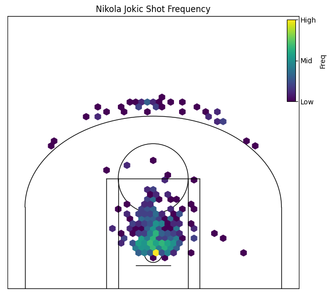

```python
shot_frequency_chart(shotchart[shotchart['PLAYER_NAME'] == 'Nikola Jokic'], 'Nikola Jokic Shot Frequency')
```

Let's look at the most common types of shots taken this season. There are dozens of different shot types, but a select few are most common. We see here that the most common shots are jump shots, pullup jump shots, and driving layup shots.

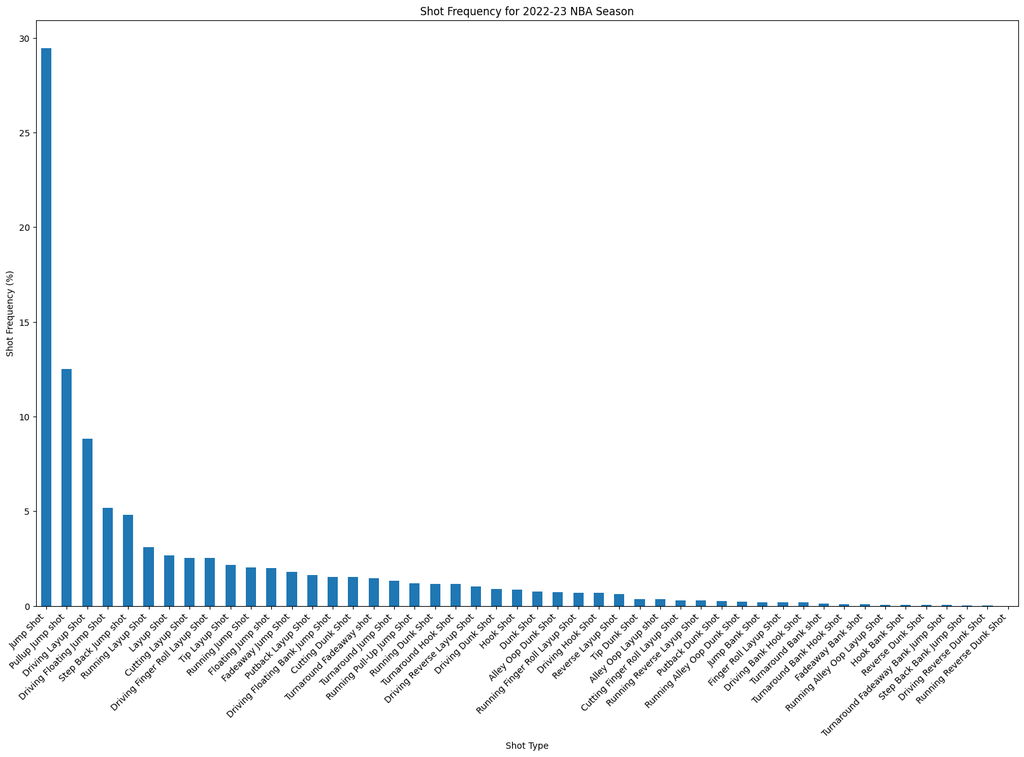

```python
fig, ax = plt.subplots(figsize=(20, 12))

# convert to percentage and plot
(100*shotchart.ACTION_TYPE.value_counts()/len(shotchart.index)).plot.bar()
ax.set_xticklabels(ax.get_xticklabels(), rotation=45, ha='right')
ax.set_title('Shot Frequency for 2022-23 NBA Season')
ax.set_xlabel('Shot Type')
ax.set_ylabel('Shot Frequency (%)')
plt.show()
```

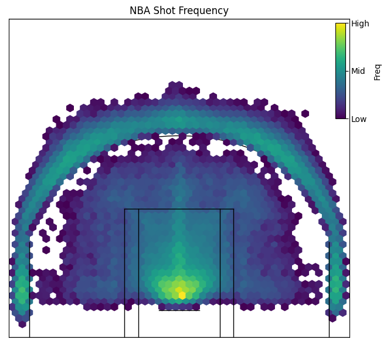

```python
shot_frequency_chart(shotchart, 'NBA Shot Frequency', mincnt=10)
```

Teams may take different shots depending on the amount of time left in the game. Let's see the entire shot chart for shots taken in the last 30 seconds of the game, in the 4th quarter. We will bump up the 'mincnt' parameter up to 3 since this is across the league, not just one player. We only want shots that are taken frequently. Interestingly, the shots taken in end of game situations are mostly shots in the paint or 3-pointers. Out of all 3 point shots, corner 3s are more common. This makes sense as they are closer to the basket. Note that these represent shot taking frequencies and not necessarily how many of these shots are actually made.

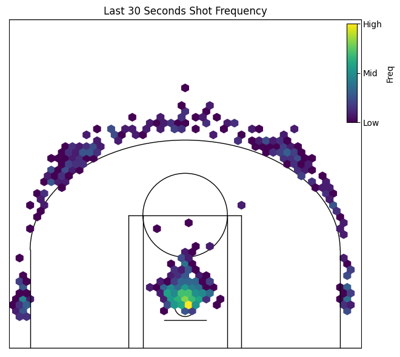

```python
last30 = shotchart[(shotchart.PERIOD == 4) & (shotchart.MINUTES_REMAINING == 0) & (shotchart.SECONDS_REMAINING < 30)]

shot_frequency_chart(last30, 'Last 30 Seconds Shot Frequency', mincnt=3)
```

Let's now look at shot accuracy across the court. This is where we will use the rounded locations computed above, because we will be aggregating overall accuracy from every spot, not just frequency. The average of the SHOT_MADE_FLAG equals the number of shots made divided by the number of shots taken, so that will be our accuracy metric. It is evident that overall shot accuracy tapers off with distance. Additionally, long 2-pointers are less accurate than 3-pointers. The most accurate shots other than layups are mid-range shots, and we also see that midrange shots from the corner are less accurate than from any other angle.

```python
def shot_accuracy_chart(chart, title):
    shot_accuracy = chart.groupby(['ROUND_LOC_X', 'ROUND_LOC_Y']).SHOT_MADE_FLAG.mean().reset_index()

    fig, ax = draw_court()
    # larger grid, adjust alpha so we don't color over the court lines
    hexbin = ax.hexbin(chart.ROUND_LOC_X, chart.ROUND_LOC_Y + 60, C=chart.SHOT_MADE_FLAG, cmap='plasma', bins=20, gridsize=32, alpha=0.8, mincnt=1, edgecolors=None, extent=(-250, 250, 422.5, -47.5))

    cbaxes = inset_axes(ax, width="3%", height="30%", loc=1)
    cb = plt.colorbar(plt.cm.ScalarMappable(cmap='plasma'), cax=cbaxes, label='Accuracy', orientation='vertical')
    cb.set_ticks([0, 0.5, 1])
    cb.set_ticklabels(['Low', 'Mid', 'High'])

    ax.set_title(title)
    plt.show()
```

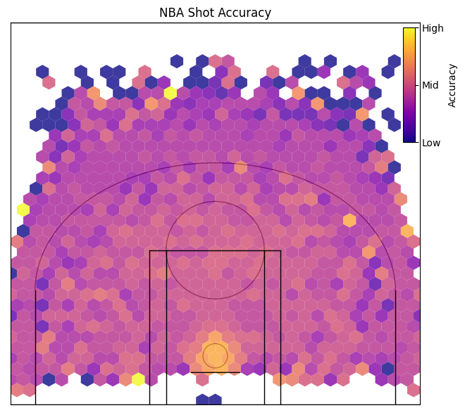

```python
shot_accuracy_chart(shotchart, 'NBA Shot Accuracy')
```

This is data from the entire NBA, but let's look at the highest and most efficient scorers. These are individuals who are top-tier scorers, and who are efficient. We first want players that average at least 20 points per game on over 8 field goal attempts, showing that these are high volume scorers. We also want players who consistently perform, so we are limiting the games started to over 41, which is half of the 82-game regular season. To get the efficient scorers, we are sorting by effective field goal percentage. Recall that effective field goal percentage weights field goal percentage for 3-pointers, counting them as 1.5 shot attempts, because they count for more points. This ensures we are not leaving out high-volume shooters whose field goal percentage is low because they are attempting more 3s than individuals who do not take those shots.

From this shot chart, we can see that in contrast to the rest of the NBA, these individuals do not take long 2-point shots, and they make mid-range shots at a much higher rate than the rest of the NBA. We see this by comparing mid-range shot accuracy to the league-wide accuracy from the chart above. Some of these spots are the elbow, free-throw line, and low-post areas. This might mean that these players are very efficient at scoring from isolation plays which can begin in these areas, or that due to the spacing created by calling mid-range shots inefficient, there is actually a lot of room between the 3-point line and paint, that these efficient top scorers use to their advantage.

We also see that shots from the right side of the court i.e. the left side from the players' perspective have an increased accuracy as opposed to the other side. This makes sense as most people are naturally right-handed, so shooting a pull-up jump shot may be more comfortable than driving all the way to the rim for a left-handed layup when the player is on that side of the court.

```python
topscorers = playershotchart[(playershotchart.PTS >= 20) & (playershotchart.FGA >= 8) & (playershotchart.GS >= 41)]

efficienttopscorers = topscorers.groupby('PLAYER_NAME').agg('mean')['eFG%'].sort_values(ascending = False).head(10)

efficientshotchart = playershotchart[playershotchart.PLAYER_NAME.isin(efficienttopscorers.index)]
efficienttopscorers
```

```
PLAYER_NAME
Nikola Jokic         0.660
Stephen Curry        0.614
Kevin Durant         0.614
Lauri Markkanen      0.586
Tyrese Haliburton    0.586
Anthony Davis        0.573
Joel Embiid          0.573
Donovan Mitchell     0.572
Kyrie Irving         0.572
Kawhi Leonard        0.572
Name: eFG%, dtype: float64
```

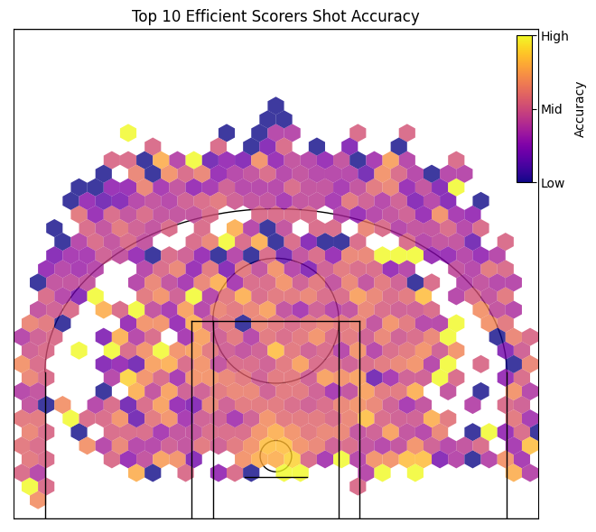

```python
shot_accuracy_chart(efficientshotchart, 'Top 10 Efficient Scorers Shot Accuracy')
```

```python
inefficientscorers = topscorers.groupby('PLAYER_NAME').agg('mean')['eFG%'].sort_values(ascending = True).head(10)

inefficientshotchart = playershotchart[playershotchart.PLAYER_NAME.isin(inefficientscorers.index)]
inefficientscorers
```

```
PLAYER_NAME
Paolo Banchero     0.465
Terry Rozier       0.484
Jalen Green        0.485
Trae Young         0.485
Ja Morant          0.504
Keldon Johnson     0.512
Jordan Poole       0.514
Dejounte Murray    0.514
Pascal Siakam      0.515
CJ McCollum        0.515
Name: eFG%, dtype: float64
```

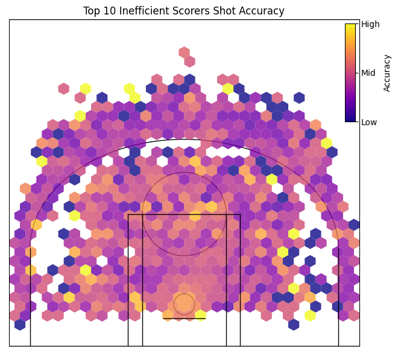

```python
shot_accuracy_chart(inefficientshotchart, 'Top 10 Inefficient Scorers Shot Accuracy')
```

What about when teams as a whole are efficient? Let's look at games where teams have caught fire from beyond the 3-point arc. Firstly, we see that these games have a high correlation with winning. The team plus-minus indicates how much a team outscored the other in a matchup, and a positive value indicates they won.

```
These teams win 80.17% of the time.
```

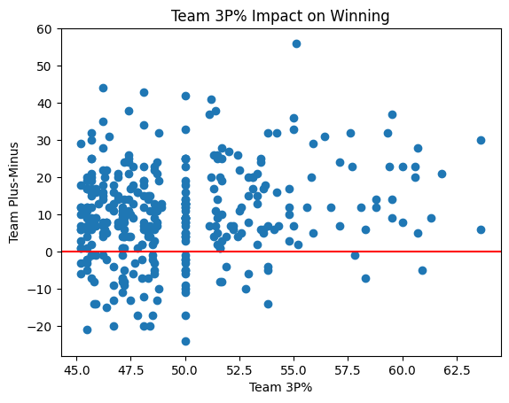

```python
high3pct = gamelog[gamelog.FG3_PCT > 0.45]

# calculating num wins / num total games
winpct = high3pct.WL.map({'W': 1, 'L': 0}).mean()
print(f'These teams win {winpct*100:0.2f}% of the time.')

plt.scatter(high3pct.FG3_PCT * 100, high3pct.PLUS_MINUS)
plt.axhline(y=0, c='r')
plt.xlabel('Team 3P%')
plt.ylabel('Team Plus-Minus')
plt.title('Team 3P% Impact on Winning')
plt.show()
```

It turns out that in these games the teams strictly aim for 3-pointers and shots in the paint. There is little to no frequency in the midrange. Long 2-point shots are avoided almost completely. So, one possible strategy for teams to reach a high 3-point shooting accuracy is to simply increase the volume of 3-pointers and mix in shots in the paint to get into a good shooting rhythm.

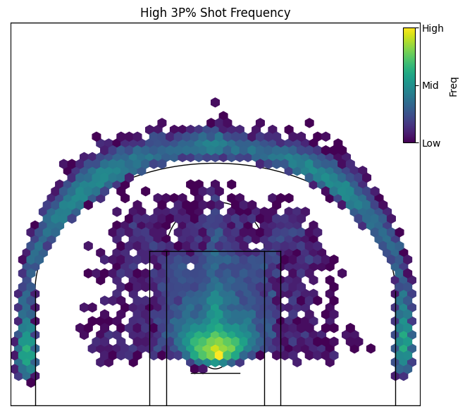

```python
shot_frequency_chart(teamshotchart[teamshotchart.FG3_PCT > 0.45], 'High 3P% Shot Frequency', mincnt=5)
```

As our final visualization, let's look at high scoring teams in general. What happens when teams score a lot of points? This too has a high correlation with winning.

```
These teams win 85.53% of the time.
```

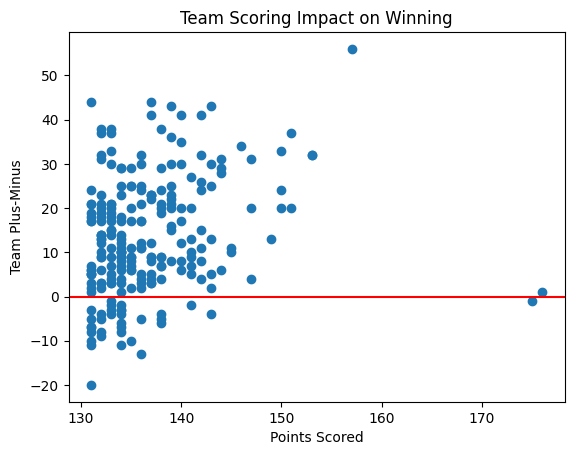

```python
highpts = gamelog[gamelog.PTS > 130]

# calculating num wins / num total games
winpct = highpts.WL.map({'W': 1, 'L': 0}).mean()
print(f'These teams win {winpct*100:0.2f}% of the time.')

plt.scatter(highpts.PTS, highpts.PLUS_MINUS)
plt.axhline(y=0, c='r')
plt.xlabel('Points Scored')
plt.ylabel('Team Plus-Minus')
plt.title('Team Scoring Impact on Winning')
plt.show()
```

High scoring games seem to be promising for teams looking to win games consistently. What types of shots do teams take during these games? The shot frequency is strikingly similar to that of the high 3-point shooting teams. In fact, an even larger portion of the midrange shows up as empty. This shows that a high volume of 3-point shooting is a good formula for high scoring games, regardless of overall accuracy.

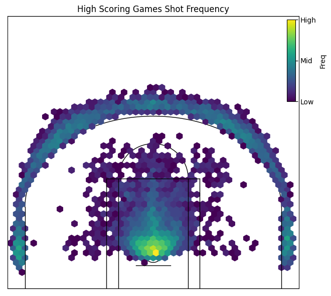

```python
shot_frequency_chart(teamshotchart[teamshotchart.PTS > 130], 'High Scoring Games Shot Frequency', mincnt=5)
```

# Modeling the Data

The following 4 models, show the effect of Field Goal %, 3-Pt Field Goal %, Defensive Rebounds, and Assists on +/-. We chose Field Goal % and 3-Pt Field Goal % since we saw earlier that these factors may be correlated with winning more games. Likewise, defensive rebounds are a factor that many NBA analysts have said decides games. Since strong defensive rebounding limits the amount of extra possessions a team earns, it can also limit the opposition's points heavily, helping teams win more games. Finally, a large number of assists may mean that more high quality shots are being created which may lead to higher field goal percentages and other high shooting attributes.

Field Goal percentage is correlated with winning. The summary shows a p-value of 0, meaning that it is statistically significant and is impactful in predicting which team wins. As a result, we can conclude that it's very important for teams to look for high quality shot attempts to keep their field goal percentage high. Specifically, it is important for teams to shoot in the areas that they are known to shoot well from like the areas in the shot charts we analyzed earlier, which may lead to a high field goal percentage.

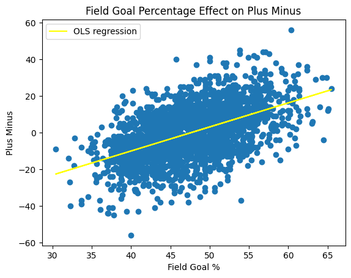

```python
fg = gamelog[['FG_PCT']] * 100
fgmodel = sma.OLS(gamelog.PLUS_MINUS, sma.add_constant(fg)).fit()

predict_y = fgmodel.predict(sma.add_constant(fg))

plt.scatter(fg, gamelog.PLUS_MINUS)
plt.plot(fg, predict_y, color = 'yellow', label = 'OLS regression')

plt.xlabel('Field Goal %')
plt.ylabel('Plus Minus')
plt.title('Field Goal Percentage Effect on Plus Minus')
plt.legend()
plt.show()
```

```python
fgmodel.summary()
```

OLS Regression Results

| Dep. Variable: | PLUS_MINUS | R-squared: | 0.264 |
| --- | --- | --- | --- |
| Model: | OLS | Adj. R-squared: | 0.263 |
| Method: | Least Squares | F-statistic: | 880.0 |
| Date: | Sat, 13 May 2023 | Prob (F-statistic): | 1.45e-165 |
| Time: | 02:52:07 | Log-Likelihood: | -9586.9 |
| No. Observations: | 2460 | AIC: | 1.918e+04 |
| Df Residuals: | 2458 | BIC: | 1.919e+04 |
| Df Model: | 1 |  |  |
| Covariance Type: | nonrobust |  |  |

|  | coef | std err | t | P>\|t\| | [0.025 | 0.975] |
| --- | --- | --- | --- | --- | --- | --- |
| const | -62.4975 | 2.121 | -29.473 | 0.000 | -66.656 | -58.339 |
| FG_PCT | 1.3112 | 0.044 | 29.664 | 0.000 | 1.225 | 1.398 |

| Omnibus: | 6.201 | Durbin-Watson: | 2.327 |
| --- | --- | --- | --- |
| Prob(Omnibus): | 0.045 | Jarque-Bera (JB): | 6.529 |
| Skew: | -0.081 | Prob(JB): | 0.0382 |
| Kurtosis: | 3.193 | Cond. No. | 423. |

Notes:  
[1] Standard Errors assume that the covariance matrix of the errors is correctly specified.

Likewise, 3 point field goal percentage is correlated with winning. The p-value is again 0, showing statistical significance, so it is important for teams to shoot well from beyond the arc. Since, teams receive more points from these shots, it makes sense that making more of these shots would help teams score more. We saw earlier that scoring more was correlated with winning. The best 3 point shots as seen in the shot charts above were the short corner 3s so teams should prioritize trying to make these shots available, because making them may lead to more wins.

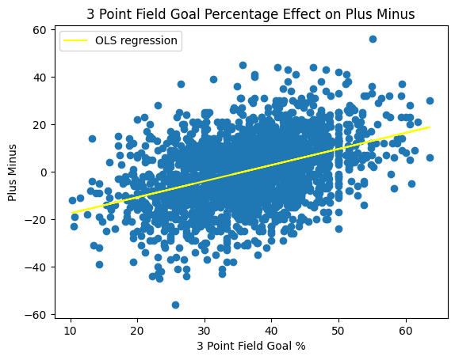

```python
fg3 = gamelog[['FG3_PCT']] * 100
fg3model = sma.OLS(gamelog.PLUS_MINUS, sma.add_constant(fg3)).fit()

predict_y = fg3model.predict(sma.add_constant(fg3))

plt.scatter(fg3, gamelog.PLUS_MINUS)
plt.plot(fg3, predict_y, color = 'yellow', label = 'OLS regression')

plt.xlabel('3 Point Field Goal %')
plt.ylabel('Plus Minus')
plt.title('3 Point Field Goal Percentage Effect on Plus Minus')
plt.legend()
plt.show()
```

```python
fg3model.summary()
```

OLS Regression Results

| Dep. Variable: | PLUS_MINUS | R-squared: | 0.173 |
| --- | --- | --- | --- |
| Model: | OLS | Adj. R-squared: | 0.173 |
| Method: | Least Squares | F-statistic: | 513.7 |
| Date: | Sat, 13 May 2023 | Prob (F-statistic): | 1.91e-103 |
| Time: | 02:52:08 | Log-Likelihood: | -9729.9 |
| No. Observations: | 2460 | AIC: | 1.946e+04 |
| Df Residuals: | 2458 | BIC: | 1.948e+04 |
| Df Model: | 1 |  |  |
| Covariance Type: | nonrobust |  |  |

|  | coef | std err | t | P>\|t\| | [0.025 | 0.975] |
| --- | --- | --- | --- | --- | --- | --- |
| const | -24.3686 | 1.105 | -22.055 | 0.000 | -26.535 | -22.202 |
| FG3_PCT | 0.6783 | 0.030 | 22.666 | 0.000 | 0.620 | 0.737 |

| Omnibus: | 6.515 | Durbin-Watson: | 2.378 |
| --- | --- | --- | --- |
| Prob(Omnibus): | 0.038 | Jarque-Bera (JB): | 7.780 |
| Skew: | -0.019 | Prob(JB): | 0.0204 |
| Kurtosis: | 3.273 | Cond. No. | 160. |

Notes:  
[1] Standard Errors assume that the covariance matrix of the errors is correctly specified.

Defensive rebounds are also correlated with winning. Again the p-score is 0 and the R-squared value is relatively positive. It is important for teams to limit offensive rebound for their opposition, by defensive rebounding well. This limits extra shots and opportunities, for the other team and may lower their scoring opportunities and points. This benefits the team that defensively rebounds well.

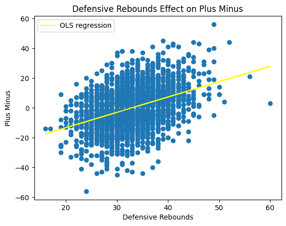

```python
dreb = gamelog[['DREB']]
drebmodel = sma.OLS(gamelog.PLUS_MINUS, sma.add_constant(dreb)).fit()

predict_y = drebmodel.predict(sma.add_constant(dreb))

plt.scatter(dreb, gamelog.PLUS_MINUS)
plt.plot(dreb, predict_y, color = 'yellow', label = 'OLS regression')
plt.xlabel('Defensive Rebounds')
plt.ylabel('Plus Minus')
plt.title('Defensive Rebounds Effect on Plus Minus')
plt.legend()
plt.show()
```

```python
drebmodel.summary()
```

OLS Regression Results

| Dep. Variable: | PLUS_MINUS | R-squared: | 0.159 |
| --- | --- | --- | --- |
| Model: | OLS | Adj. R-squared: | 0.159 |
| Method: | Least Squares | F-statistic: | 465.0 |
| Date: | Sat, 13 May 2023 | Prob (F-statistic): | 1.36e-94 |
| Time: | 02:52:08 | Log-Likelihood: | -9750.2 |
| No. Observations: | 2460 | AIC: | 1.950e+04 |
| Df Residuals: | 2458 | BIC: | 1.952e+04 |
| Df Model: | 1 |  |  |
| Covariance Type: | nonrobust |  |  |

|  | coef | std err | t | P>\|t\| | [0.025 | 0.975] |
| --- | --- | --- | --- | --- | --- | --- |
| const | -34.0091 | 1.598 | -21.282 | 0.000 | -37.143 | -30.876 |
| DREB | 1.0305 | 0.048 | 21.563 | 0.000 | 0.937 | 1.124 |

| Omnibus: | 4.772 | Durbin-Watson: | 2.361 |
| --- | --- | --- | --- |
| Prob(Omnibus): | 0.092 | Jarque-Bera (JB): | 5.269 |
| Skew: | -0.040 | Prob(JB): | 0.0718 |
| Kurtosis: | 3.212 | Cond. No. | 208. |

Notes:  
[1] Standard Errors assume that the covariance matrix of the errors is correctly specified.

Finally, assists are also correlated with winning. Moving the ball is important as it forces the defense to move around, increasing the potential for an open shot from a high percentage area. Since we know field goal percentage and quality shots lead to winning games, passing the ball well is very important for a team's success.

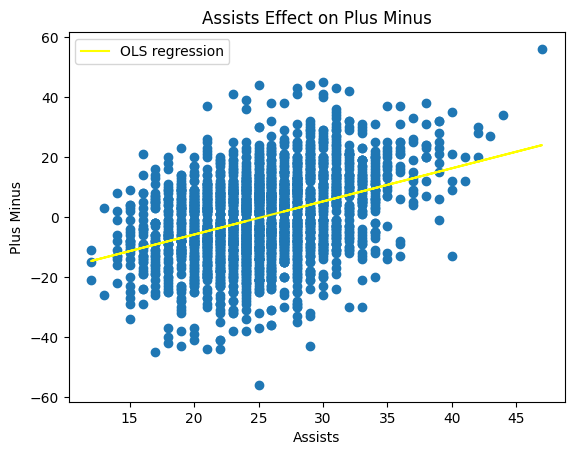

```python
ast = gamelog[['AST']]
astmodel = sma.OLS(gamelog.PLUS_MINUS, sma.add_constant(ast)).fit()

predict_y = astmodel.predict(sma.add_constant(ast))

plt.scatter(ast, gamelog.PLUS_MINUS)
plt.plot(ast, predict_y, color = 'yellow', label = 'OLS regression')

plt.xlabel('Assists')
plt.ylabel('Plus Minus')
plt.title('Assists Effect on Plus Minus')
plt.legend()
plt.show()
```

```python
astmodel.summary()
```

OLS Regression Results

| Dep. Variable: | PLUS_MINUS | R-squared: | 0.152 |
| --- | --- | --- | --- |
| Model: | OLS | Adj. R-squared: | 0.152 |
| Method: | Least Squares | F-statistic: | 440.9 |
| Date: | Sat, 13 May 2023 | Prob (F-statistic): | 3.62e-90 |
| Time: | 02:52:09 | Log-Likelihood: | -9760.4 |
| No. Observations: | 2460 | AIC: | 1.952e+04 |
| Df Residuals: | 2458 | BIC: | 1.954e+04 |
| Df Model: | 1 |  |  |
| Covariance Type: | nonrobust |  |  |

|  | coef | std err | t | P>\|t\| | [0.025 | 0.975] |
| --- | --- | --- | --- | --- | --- | --- |
| const | -27.9444 | 1.356 | -20.613 | 0.000 | -30.603 | -25.286 |
| AST | 1.1038 | 0.053 | 20.997 | 0.000 | 1.001 | 1.207 |

| Omnibus: | 17.982 | Durbin-Watson: | 2.398 |
| --- | --- | --- | --- |
| Prob(Omnibus): | 0.000 | Jarque-Bera (JB): | 20.265 |
| Skew: | -0.152 | Prob(JB): | 3.98e-05 |
| Kurtosis: | 3.324 | Cond. No. | 136. |

Notes:  
[1] Standard Errors assume that the covariance matrix of the errors is correctly specified.

Let's now use these factors which we know are correlated with winning in constructing a general prediction model for team +/-. We will try to predict the 2022 NBA champion Golden State Warriors' performance throughout this current season. We start by constructing a dataset excluding the Warriors, so that the Warriors games are out-of-sample. Then we will run a multivariate OLS regression including each of FG%, 3FG%, DREB, and AST as factors. The model does a fairly accurate job of predicting the Warriors +/- given the other variables of these games. However, what we really care about is whether they won or not. We compare the sign of the +/- (1 in a win, -1 in a loss) and find that our OLS regression is roughly 82% accurate in predicting Warriors wins.

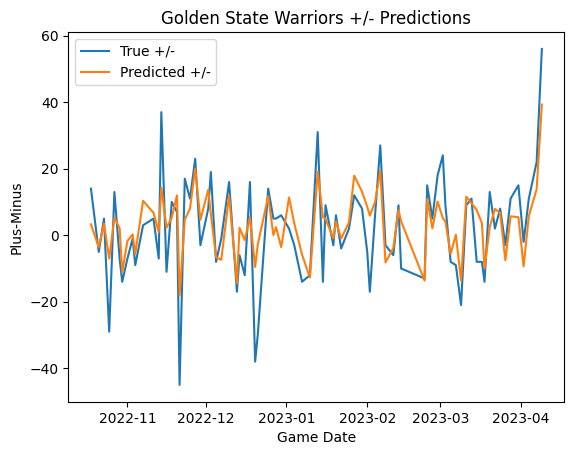

```
Win prediction accuracy: 81.71%
```

```python
# separate warriors games, and all other games by dropping warriors games
warriors = gamelog[gamelog.TEAM_ABBREVIATION == 'GSW']
predmodel = sma.formula.ols('PLUS_MINUS ~ FG_PCT + FG3_PCT + DREB + AST', data = gamelog.drop(warriors.index)).fit()

plt.plot(pd.to_datetime(warriors.GAME_DATE), warriors.PLUS_MINUS, label='True +/-')

ypred = predmodel.predict(sma.add_constant(warriors[['FG_PCT', 'FG3_PCT', 'DREB', 'AST']]))
plt.plot(pd.to_datetime(warriors.GAME_DATE), ypred, label='Predicted +/-')
plt.xlabel('Game Date')
plt.ylabel('Plus-Minus')
plt.title('Golden State Warriors +/- Predictions')
plt.legend()
plt.show()

# on average, how often did we get the win prediction correct?
model_accuracy = (np.sign(warriors.PLUS_MINUS) == np.sign(ypred)).mean() * 100
print(f'Win prediction accuracy: {model_accuracy:0.2f}%')
```

As expected, teams that shoot at both a high rate and high accuracy (1 standard deviation above the mean) are very likely to win games. We see this from the level curve drawn on the top right, representing the boundary for a prediction of 1 (win). However, a much higher percentage is required to win consistently if a team takes few attempts. At the same time, teams can get away with lower accuracy if they shoot a high volume of 3-pointers. We see this from the middle boundary representing the midpoint value of 0.5. This is a downward sloping line, which means teams can make up for poor shooting percentages with increased frequency, and vice versa.

To learn more about Support Vector Machines see: https://towardsdatascience.com/support-vector-machine-introduction-to-machine-learning-algorithms-934a444fca47?gi=049569c0381a

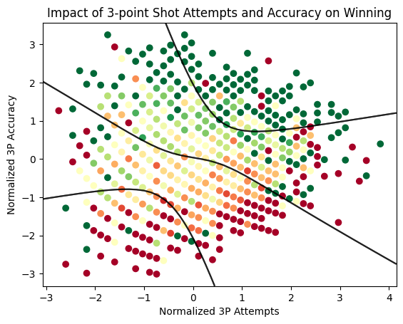

```python
from sklearn.preprocessing import StandardScaler

scaler = StandardScaler()

X = gamelog[['FG3A', 'FG3_PCT']]
Xnorm = scaler.fit_transform(X)
Y = gamelog.WL.map({'W': 1, 'L': 0})

clf = svm.SVC(kernel='sigmoid', C=10)
clf.fit(Xnorm, Y)

# create a separate dataframe for plotting
Xplot = pd.DataFrame({'FG3A': Xnorm[:, 0], 'FG3_PCT': Xnorm[:, 1], 'WL': Y})

# get win % for every data point
Xplot = Xplot.groupby(['FG3A', 'FG3_PCT'], as_index=False).agg({'WL': 'mean'})
plt.scatter(Xplot.FG3A, Xplot.FG3_PCT, c=Xplot.WL, cmap='RdYlGn')
ax = plt.gca()
xlim = ax.get_xlim()
ylim = ax.get_ylim()

# create the input axes for the contour plot
x, y = np.meshgrid(np.linspace(xlim[0], xlim[1], 50),
                     np.linspace(ylim[0], ylim[1], 50))

# given these inputs, apply the function on it for deciding win, loss, or in between
Z = clf.decision_function(np.c_[x.ravel(), y.ravel()])
Z = Z.reshape(x.shape)

ax.contour(x, y, Z, colors='k', levels=[0, 0.5, 1], alpha=0.5)
plt.xlabel('Normalized 3P Attempts')
plt.ylabel('Normalized 3P Accuracy')
plt.title('Impact of 3-point Shot Attempts and Accuracy on Winning')

plt.show()
```

In our exploratory data analysis, we made multiple claims about certain spots on the court being more efficient to shoot from than others. Here we will justify those claims using K-Means clustering. This is a method that allows us to separate spatial data into distinct groups based on the concentration of points in every group. We will start off by clustering 3-point shots on the court and limiting them to 32 feet or less to prevent longer shots, which are uncommon, from skewing the percentages.

You can read more about K-means clustering here: https://neptune.ai/blog/k-means-clustering

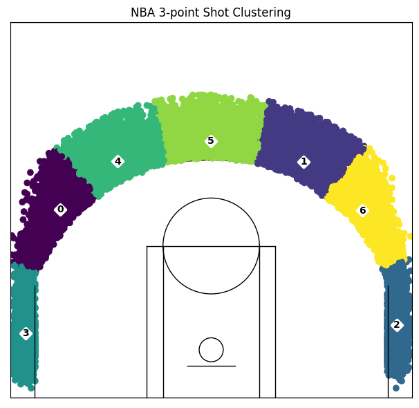

```python
shotchart3pt = playershotchart[(shotchart.SHOT_TYPE == '3PT Field Goal') & (shotchart.SHOT_DISTANCE < 32)].copy()

kmeans = cluster.KMeans(n_clusters=7)
kmeans.fit(shotchart3pt[['LOC_X', 'LOC_Y']])

labels = kmeans.labels_
centroids = kmeans.cluster_centers_

# assign cluster to every shot chart point
shotchart3pt['cluster'] = labels

fig, ax = draw_court()
ax.scatter(shotchart3pt.LOC_X, shotchart3pt.LOC_Y + 60, c=labels)
ax.scatter(centroids[:, 0], centroids[:, 1] + 60, marker='D', s=60, linewidths=3, color='white')

# label centroids by number
for i in range(centroids.shape[0]):
    plt.text(centroids[i, 0], centroids[i, 1] + 60, i, ha='center', va='center', fontweight='bold')

plt.title('NBA 3-point Shot Clustering')
plt.show()
```

```python
cluster_accuracy = {'Group': [], 'FG%': []}

for group, df in shotchart3pt.groupby('cluster'):
    cluster_accuracy['Group'].append(f'3pt-{group}')

    # shot made flag is 1 if made, 0 if missed. mean = FG%
    cluster_accuracy['FG%'].append(df.SHOT_MADE_FLAG.mean())

best3pt = pd.DataFrame(cluster_accuracy).sort_values(by='FG%', ascending=False)
display(best3pt)
```

|  | Group | FG% |
| --- | --- | --- |
| 3 | 3pt-3 | 0.385968 |
| 2 | 3pt-2 | 0.385701 |
| 0 | 3pt-0 | 0.364336 |
| 6 | 3pt-6 | 0.360587 |
| 5 | 3pt-5 | 0.351925 |
| 4 | 3pt-4 | 0.351387 |
| 1 | 3pt-1 | 0.349791 |

Let's apply the same clustering to 2-point shots, but bump up the clusters to 9 so that we can properly divide the many mid-range shots and shots in the paint.

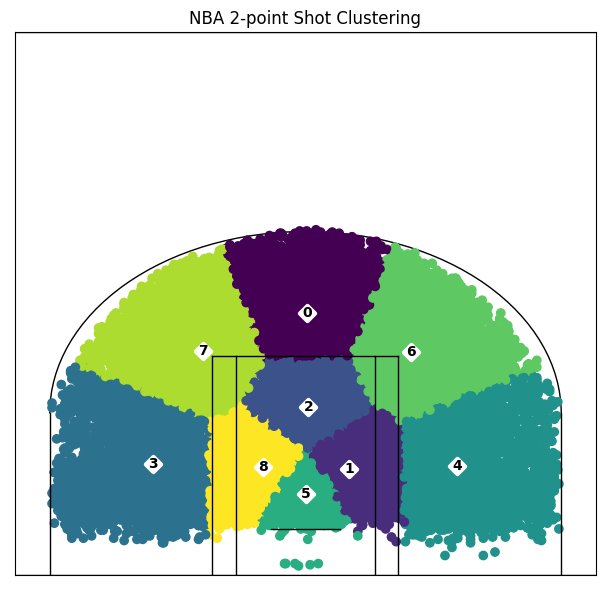

```python
shotchart2pt = playershotchart[(shotchart.SHOT_TYPE == '2PT Field Goal')].copy()

kmeans = cluster.KMeans(n_clusters=9)
kmeans.fit(shotchart2pt[['LOC_X', 'LOC_Y']])

labels = kmeans.labels_
centroids = kmeans.cluster_centers_

# assign cluster to every shot chart point
shotchart2pt['cluster'] = labels

fig, ax = draw_court()
ax.scatter(shotchart2pt.LOC_X, shotchart2pt.LOC_Y + 60, c=labels)
ax.scatter(centroids[:, 0], centroids[:, 1] + 60, marker='D', s=60, linewidths=3, color='white')

# label centroids by number
for i in range(centroids.shape[0]):
    plt.text(centroids[i, 0], centroids[i, 1] + 60, i, ha='center', va='center', fontweight='bold')

plt.title('NBA 2-point Shot Clustering')
plt.show()
```

Obviously, the best spot to shoot a 2-pointer is in the cluster right under the basket. The 3 other clusters in the paint are the next most efficient. The worst shots to take are in clusters corresponding to baseline mid-range shots. Recall that in our visualization of inefficient shooters, these shots were especially common. The best mid-range jumper is in the cluster right at the top of the free-throw line.

```python
cluster_accuracy = {'Group': [], 'FG%': []}

for group, df in shotchart2pt.groupby('cluster'):
    cluster_accuracy['Group'].append(f'2pt-{group}')

    # shot made flag is 1 if made, 0 if missed. mean = FG%
    cluster_accuracy['FG%'].append(df.SHOT_MADE_FLAG.mean())

best2pt = pd.DataFrame(cluster_accuracy).sort_values(by='FG%', ascending=False)
display(best2pt)
```

|  | Group | FG% |
| --- | --- | --- |
| 5 | 2pt-5 | 0.693712 |
| 2 | 2pt-2 | 0.461780 |
| 1 | 2pt-1 | 0.459776 |
| 8 | 2pt-8 | 0.444999 |
| 0 | 2pt-0 | 0.436711 |
| 6 | 2pt-6 | 0.433483 |
| 7 | 2pt-7 | 0.426893 |
| 3 | 2pt-3 | 0.414599 |
| 4 | 2pt-4 | 0.414085 |

Let's now apply the same method that we discussed regarding the eFG% metric. 3-pointers are worth 1.5x as much as 2-pointers, so we want to weight the shot percentage for those accordingly in order to reasonably compare them to 2-pointers. Now we can see clusters with the best overall efficiency. Aside from shots right under the basket, every type of 3-pointer is more efficient than any other 2-pointer. Recall that the most efficient shooting teams, along with the highest scoring teams, focused on strictly 3-pointers and shots in the paint. We now see statistical evidence supporting this decision. The highest percentage 2-pointer outside of a layup falls at a 46% rate on average. The worst 3-pointer statistically is made roughly 35% of the time.

```python
best3pt['eFG%'] = best3pt['FG%'] * 1.5
best2pt['eFG%'] = best2pt['FG%']
besteFG = pd.concat([best2pt, best3pt]).sort_values(by='eFG%', ascending=False).reset_index()[['Group', 'eFG%']]
display(besteFG)
```

|  | Group | eFG% |
| --- | --- | --- |
| 0 | 2pt-5 | 0.693712 |
| 1 | 3pt-3 | 0.578952 |
| 2 | 3pt-2 | 0.578551 |
| 3 | 3pt-0 | 0.546504 |
| 4 | 3pt-6 | 0.540880 |
| 5 | 3pt-5 | 0.527887 |
| 6 | 3pt-4 | 0.527081 |
| 7 | 3pt-1 | 0.524687 |
| 8 | 2pt-2 | 0.461780 |
| 9 | 2pt-1 | 0.459776 |
| 10 | 2pt-8 | 0.444999 |
| 11 | 2pt-0 | 0.436711 |
| 12 | 2pt-6 | 0.433483 |
| 13 | 2pt-7 | 0.426893 |
| 14 | 2pt-3 | 0.414599 |
| 15 | 2pt-4 | 0.414085 |

# Interpreting the Data

Insight/Decisions: As seen throughout our analysis, the kind of shots teams and players take matters. With data from the NBA API and Basketball Reference, we can see that shooting from different areas and the ability to take and make good shots at a high rate are what separates good players from great players. The more points a team scores the more likely they are to win games, so teams have to prioritize taking good high percentage shots. 3s in the corner, shots in the paint, and mid-range shots away from the baseline tend to be great places for teams to shoot from, so teams potentially need to work on these kinds of shots more. Other factors like defensively rebounding well and passing the ball are also very important to the outcome of games. Our model of combined factors such as field goal percentage, 3 point field goal percentage, defensive rebounding, and assists was able to accurately predict the outcome of recent games for teams such as Golden State, and shows that there is a clear need for teams to emphasize these points of play in their gameplans. While our analysis does not take into account all factors of basketball, it does show that shooting more 3s and playing a strong team game with good fundamentals is what wins games. Analysts tend to use the phrase "passing the eye-test" for teams that pass well and take high percentage shots. Our analysis shows this is indeed correlated with winning basketball. Our analysis also shows that inefficient shot-taking and shot-hunting hurts teams in the long run, and that some players who are glorified as great shot-creators may in fact be hurting their teams, because of their inefficiencies.

We hope that reading this tutorial about NBA shooting and shot charts inspires you to learn more about basketball and data science, and we hope you tune in to the rest of the NBA playoffs!

[figure not shown]

Created in Deepnote